# M3Decomposition

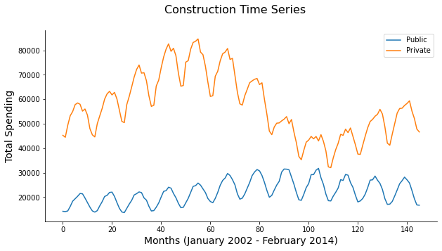

```python
import pandas as pd
import matplotlib.pyplot as plt
import numpy as np
%matplotlib inline
df = pd.read_csv(r"C:\Users\kevin\CTBA\M3\ConstructionTimeSeriesDataV2.csv")
x1= df['Private Construction']
x2= df['Public Construction']
fig, ax = plt.subplots()
fig.suptitle('Construction Time Series',size='16')
ax.spines['right'].set_visible(False)
ax.spines['top'].set_visible(False)
ax.set_xlabel('Months (January 2002 - February 2014)',fontsize='14')
ax.set_ylabel('Total Spending', fontsize='14')
plt.plot(x2, label= 'Public')
plt.plot(x1, label= 'Private')
plt.legend()
fig.set_size_inches(10,5)
plt.show()
```

## Take a look at the data

- We can visualize the different trend between public construction and private construction.
- Let's decompose each one to get more understanding.

## Private Construction

- It is a nonlinear trend. We will use the additive model: Spending = Trend + Cyclictity + Irregular
- First, we are going to compute the trend, the moving average, by replacing each point with the average of the periods in a window. Then, we are computing the squared errors:

```
Average Squared Error per Month:  37395667.05489795
            Month Month-Year  Total Construction  Private Construction  \
2003-07-31     19     Jul-03               82971                 62216
2003-08-31     20     Aug-03               85191                 63234
2003-09-30     21     Sep-03               83841                 61767
2003-10-31     22     Oct-03               83133                 62813
2003-11-30     23     Nov-03               77915                 60115
...           ...        ...                 ...                   ...
2012-04-30    124     Apr-12               66223                 44964
2012-05-31    125     May-12               72240                 48342
2012-06-30    126     Jun-12               77876                 50900
2012-07-31    127     Jul-12               78897                 51794
2012-08-31    128     Aug-12               81712                 53073

            Public Construction        Date        MovAvg         sqErr
2003-07-31                20755  2003-07-31  57969.430556  1.803335e+07
2003-08-31                21957  2003-08-31  58314.944444  2.419711e+07
2003-09-30                22075  2003-09-30  58718.902778  9.290897e+06
2003-10-31                20321  2003-10-31  59143.555556  1.346482e+07
2003-11-30                17801  2003-11-30  59593.541667  2.719188e+05
...                         ...         ...           ...           ...
2012-04-30                21259  2012-04-30  46543.069444  2.493460e+06
2012-05-31                23898  2012-05-31  46907.194444  2.058667e+06
2012-06-30                26975  2012-06-30  47262.611111  1.323060e+07
2012-07-31                27104  2012-07-31  47660.583333  1.708513e+07
2012-08-31                28640  2012-08-31  48077.638889  2.495363e+07

[110 rows x 8 columns]
```

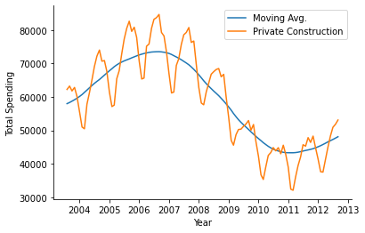

```python
date_data = {'Jan' : ('01', '31'), 'Feb' : ('02', '28'), 'Mar' : ('03', '31'), 'Apr' : ('04', '30'), 'May' : ('05', '31'), 'Jun' : ('06', '30'), 'Jul' : ('07', '31'), 'Aug' : ('08', '31'), 'Sep' : ('09', '30'), 'Oct' : ('10', '31'), 'Nov' : ('11', '30'), 'Dec' : ('12', '31')}

def to_data_range(date_str):
    return '20' + date_str[-2:] + '-' + date_data[date_str[:3]][0] + '-' + date_data[date_str[:3]][1]
df['Date'] = df['Month-Year'].apply(to_data_range)
df.index = pd.date_range(start=df['Date'].iloc[0], end=df['Date'].iloc[df.shape[0] - 1], freq='M')

def sqErr(row):
    return (row['Private Construction'] - row['MovAvg'])**2

df['MovAvg'] = np.NaN
df['sqErr'] = np.NaN

window = 36
window = window - window % 2

for i in range(int(window/2),df.shape[0]-int(window/2)):
    df.loc[df.index[i],'MovAvg'] = (0.5*df.iloc[i - int(window/2)]['Private Construction'] + df.iloc[i - int(window/2)+1:i + int(window/2)]['Private Construction'].sum() + 0.5*df.iloc[i + int(window/2)]['Private Construction'])/float(window)

df['sqErr'] = (df['Private Construction'] - df['MovAvg'])**2

df.dropna(how='any',inplace=True)

fig,ax = plt.subplots()
ax.plot(df['MovAvg'],label='Moving Avg.')
ax.plot(df['Private Construction'],label='Private Construction')
ax.set_xlabel('Year')
ax.set_ylabel('Total Spending')
ax.spines['right'].set_visible(False)
ax.spines['top'].set_visible(False)
plt.legend()
print('Average Squared Error per Month: ',sum(df['sqErr'])/len(df))
print(df)
```

- Next step, let's subtract the moving average from the total spending of Private Construction to obtain the remaining pattern ,and the average residual that is the total of Cyclicity and Irregular.

```
Average Residual:  113.25315656565621
```

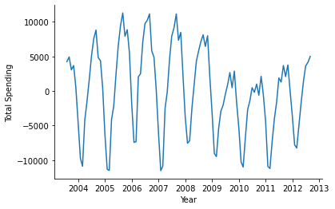

```python
df['R1'] = df['Private Construction'] - df['MovAvg']
df['R1Error'] = abs((df['Private Construction'] - df['R1'])/df['Private Construction'])
df.style.format
({'MovAvg': '{:.1f}'.format,
'sqErr': '{:,.1f}'.format,
'R1': '{:,.1f}'.format,
'R1Error': '{:,.3f}'.format})

fig,ax = plt.subplots()
ax.plot(df['R1'])
ax.set_xlabel('Year')
ax.set_ylabel('Total Spending')
ax.spines['right'].set_visible(False)
ax.spines['top'].set_visible(False)
print('Average Residual: ', sum(df['R1'])/len(df))
```

- We will use the autocorrelation to find out any repeating patterns:

```python
maxCorr = 0.0
period = np.NaN
for i in range(1,37):
    corr = df['R1'].autocorr(lag=i)
    print('Correlation, lag ',i,'   ',corr)
    if corr > maxCorr:
        maxCorr = corr
        period = i
print('period = ',period,'     Maximum Correlation = ',maxCorr)
```

```
Correlation, lag  1     0.8250475036301713
Correlation, lag  2     0.4820939752221447
Correlation, lag  3     0.0661838628463355
Correlation, lag  4     -0.29310582259154694
Correlation, lag  5     -0.5386625150984725
Correlation, lag  6     -0.6496282831082484
Correlation, lag  7     -0.549838477475518
Correlation, lag  8     -0.3185413831731613
Correlation, lag  9     0.02011606382325631
Correlation, lag  10     0.41176952584284515
Correlation, lag  11     0.7322731003955263
Correlation, lag  12     0.8944851710984221
Correlation, lag  13     0.7299213692607464
Correlation, lag  14     0.4055214152186815
Correlation, lag  15     0.0031237974667481893
Correlation, lag  16     -0.34159925855108353
Correlation, lag  17     -0.5745510163732713
Correlation, lag  18     -0.681216824190257
Correlation, lag  19     -0.5902172854543253
Correlation, lag  20     -0.37531995989940625
Correlation, lag  21     -0.04750388422754723
Correlation, lag  22     0.3369494305895757
Correlation, lag  23     0.6572135458224128
Correlation, lag  24     0.8250377247910974
Correlation, lag  25     0.6796473144842703
Correlation, lag  26     0.3697716757524485
Correlation, lag  27     -0.031763738440921285
Correlation, lag  28     -0.3864486695652997
Correlation, lag  29     -0.629267851757631
Correlation, lag  30     -0.7352864412725051
Correlation, lag  31     -0.6386019116542909
Correlation, lag  32     -0.42297520217029344
Correlation, lag  33     -0.09831675443648784
Correlation, lag  34     0.281952534008814
Correlation, lag  35     0.6041349156276149
Correlation, lag  36     0.786554093702412
period =  12      Maximum Correlation =  0.8944851710984221
```

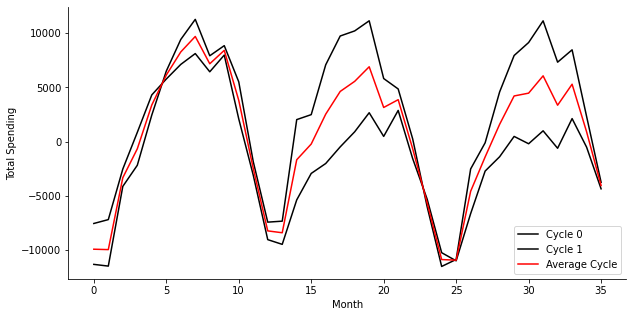

```python
period = 36
cycleLen = period
numCycles = int(len(df)/cycleLen + 0.5)
cycles = [df.iloc[range(i*period,min((i+1)*period,len(df)))]['R1'] for i in range(numCycles)]
ptsInCycles = [df.iloc[range(i,len(df['R1']),period)]['R1'].tolist() for i in range(period)]
avg = [sum(pts)/len(pts) for pts in ptsInCycles]

fig,ax = plt.subplots()
for i in range(len(cycles)):
    ax.plot(cycles[i].values,label='Cycle '+str(i),c='k')
ax.plot(avg,label='Average Cycle',c='r')
ax.set_xlabel('Month')
ax.set_ylabel('Total Spending')
ax.spines['right'].set_visible(False)
ax.spines['top'].set_visible(False)
fig.set_size_inches(10,5)
ax.legend(loc=4)
```

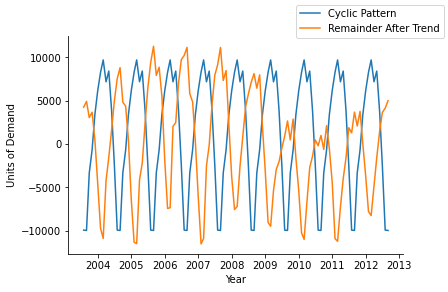

```python
cycleLen = period
numCycles = int(len(df)/cycleLen + 0.5)
df['C'] = np.NaN
for i in range(len(df)):
    df.loc[df.index[i], 'C'] = avg[i % cycleLen]

fig,ax = plt.subplots()
ax.plot(df['C'],label='Cyclic Pattern')
ax.plot(df['R1'],label='Remainder After Trend')
ax.set_xlabel('Year')
ax.set_ylabel('Units of Demand')
ax.spines['right'].set_visible(False)
ax.spines['top'].set_visible(False)
fig.legend()
```

- To get the R2, we subtract the R1 and C1 which will show the remainder error or Irregular. Then, we will see the R2 relative to the original data series of Private Construction:

```
Average Error:  0.1949321926797825
            Month Month-Year  Total Construction  Private Construction  \
2003-07-31     19     Jul-03               82971                 62216
2003-08-31     20     Aug-03               85191                 63234
2003-09-30     21     Sep-03               83841                 61767
2003-10-31     22     Oct-03               83133                 62813
2003-11-30     23     Nov-03               77915                 60115
...           ...        ...                 ...                   ...
2012-04-30    124     Apr-12               66223                 44964
2012-05-31    125     May-12               72240                 48342
2012-06-30    126     Jun-12               77876                 50900
2012-07-31    127     Jul-12               78897                 51794
2012-08-31    128     Aug-12               81712                 53073

            Public Construction        Date        MovAvg           R1  \
2003-07-31                20755  2003-07-31  57969.430556  4246.569444
2003-08-31                21957  2003-08-31  58314.944444  4919.055556
2003-09-30                22075  2003-09-30  58718.902778  3048.097222
2003-10-31                20321  2003-10-31  59143.555556  3669.444444
2003-11-30                17801  2003-11-30  59593.541667   521.458333
...                         ...         ...           ...          ...
2012-04-30                21259  2012-04-30  46543.069444 -1579.069444
2012-05-31                23898  2012-05-31  46907.194444  1434.805556
2012-06-30                26975  2012-06-30  47262.611111  3637.388889
2012-07-31                27104  2012-07-31  47660.583333  4133.416667
2012-08-31                28640  2012-08-31  48077.638889  4995.361111

             R1Error            C            R2   R2Error           fit
2003-07-31  0.931745 -9929.518519  14176.087963  0.227853  48039.912037
2003-08-31  0.922209 -9966.226852  14885.282407  0.235400  48348.717593
2003-09-30  0.950652 -3333.826389   6381.923611  0.103323  55385.076389
2003-10-31  0.941581  -668.819444   4338.263889  0.069066  58474.736111
2003-11-30  0.991326  3376.513889  -2855.055556  0.047493  62970.055556
...              ...          ...           ...       ...           ...
2012-04-30  1.035119  8415.673611  -9994.743056  0.222283  54958.743056
2012-05-31  0.970320  3804.576389  -2369.770833  0.049021  50711.770833
2012-06-30  0.928539 -2472.208333   6109.597222  0.120031  44790.402778
2012-07-31  0.920195 -9929.518519  14062.935185  0.271517  37731.064815
2012-08-31  0.905878 -9966.226852  14961.587963  0.281906  38111.412037

[110 rows x 13 columns]
```

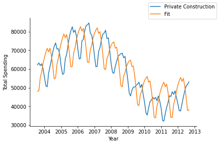

```python
df['R2'] = df['R1'] - df['C']
df['R2Error'] = abs(df['R2']/df['Private Construction'])
df['fit'] = df['MovAvg'] + df['C']
df.drop(['sqErr'],axis=1,inplace=True)
print('Average Error: ', sum(df['R2Error'])/len(df))
print(df)
fig,ax = plt.subplots()
ax.plot(df['Private Construction'],label='Private Construction')
ax.plot(df['fit'], label = 'Fit')
ax.set_xlabel('Year')
ax.set_ylabel('Total Spending')
ax.spines['right'].set_visible(False)
ax.spines['top'].set_visible(False)
fig.legend()
```

- Finally, let's see the model versus the original data:

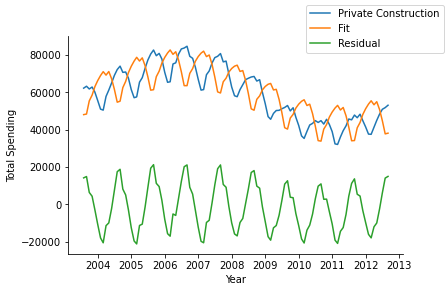

```python
fig,ax = plt.subplots()
ax.plot(df['Private Construction'],label='Private Construction')
ax.plot(df['fit'],label='Fit')
ax.plot(df['R2'],label='Residual')
ax.set_xlabel('Year')
ax.set_ylabel('Total Spending')
ax.spines['right'].set_visible(False)
ax.spines['top'].set_visible(False)
fig.legend()
```

## Public Construction

- It is linear trend, and we will use the formula: Total Spending = Trend + Level + Seasonality + Remainder
- We are using the linear regression analysis to find out the slope and intercept:

```python
from scipy import stats

slope, intercept, r_value, p_value, std_err = stats.linregress(df.index,df['Public Construction'])
print('intercept =', intercept, '    slope =', slope, '     p_value = ',p_value)
```

```
intercept = 18327.939893765724     slope = 52.00857586303297      p_value =  3.028349007007645e-09
```

- We are going to take out the level and the trend from original data to see the remainings, and called "R1".

```
     Month Month-Year  Total Construction  Private Construction  \
0        1     Jan-02               59516                 45273
1        2     Feb-02               58588                 44475
2        3     Mar-02               63782                 49396
3        4     Apr-02               69504                 53283
4        5     May-02               73384                 55009
..     ...        ...                 ...                   ...
141    142     Oct-13               85193                 59370
142    143     Nov-13               77931                 55191
143    144     Dec-13               71502                 52132
144    145     Jan-14               64661                 47827
145    146     Feb-14               63368                 46647

     Public Construction       regress           R1
0                  14243  18379.948470 -4136.948470
1                  14113  18431.957045 -4318.957045
2                  14386  18483.965621 -4097.965621
3                  16221  18535.974197 -2314.974197
4                  18375  18587.982773  -212.982773
..                   ...           ...          ...
141                25823  25713.157666   109.842334
142                22741  25765.166242 -3024.166242
143                19369  25817.174818 -6448.174818
144                16834  25869.183394 -9035.183394
145                16721  25921.191970 -9200.191970

[146 rows x 7 columns]
```

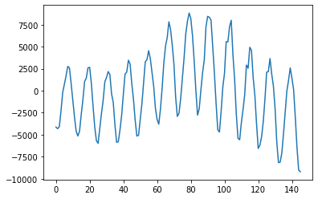

```python
def create_regress_col(row, intercept, slope):
    return float(intercept) + float(row['Month']) * slope

df['regress'] = df.apply(create_regress_col,args = (intercept,slope),axis = "columns")
df['R1'] = df['Public Construction'] - df['regress']
df.style.format({
    'Public Construction': '{:,.0f}'.format,
    'regress': '{:,.0f}'.format,
    'R1': '{:,.0f}'.format
})
print(df)
plt.plot(df.index,df.R1)
```

- Computing the autocorrelation:

```
<bound method NDFrame.head of      Month Month-Year  Total Construction  Private Construction  \
0        1     Jan-02               59516                 45273
1        2     Feb-02               58588                 44475
2        3     Mar-02               63782                 49396
3        4     Apr-02               69504                 53283
4        5     May-02               73384                 55009
..     ...        ...                 ...                   ...
141    142     Oct-13               85193                 59370
142    143     Nov-13               77931                 55191
143    144     Dec-13               71502                 52132
144    145     Jan-14               64661                 47827
145    146     Feb-14               63368                 46647

     Public Construction       regress           R1  lag18    lag36
0                  14243  18379.948470 -4136.948470    NaN      NaN
1                  14113  18431.957045 -4318.957045    NaN      NaN
2                  14386  18483.965621 -4097.965621    NaN      NaN
3                  16221  18535.974197 -2314.974197    NaN      NaN
4                  18375  18587.982773  -212.982773    NaN      NaN
..                   ...           ...          ...    ...      ...
141                25823  25713.157666   109.842334    NaN  27931.0
142                22741  25765.166242 -3024.166242    NaN  25215.0
143                19369  25817.174818 -6448.174818    NaN  21274.0
144                16834  25869.183394 -9035.183394    NaN  18578.0
145                16721  25921.191970 -9200.191970    NaN  18475.0

[146 rows x 9 columns]>
autocorrelation, lag = 0 : 0.9999999999999998
autocorrelation, lag = 1 : 0.8856280681661074
autocorrelation, lag = 2 : 0.6013224790427005
autocorrelation, lag = 3 : 0.2158670848758824
autocorrelation, lag = 4 : -0.16610636997182948
autocorrelation, lag = 5 : -0.42768100297253503
autocorrelation, lag = 6 : -0.5179874711984134
autocorrelation, lag = 7 : -0.41832063408165815
autocorrelation, lag = 8 : -0.15136655336477844
autocorrelation, lag = 9 : 0.21954961123223027
autocorrelation, lag = 10 : 0.5790216579473368
autocorrelation, lag = 11 : 0.8451120068400936
autocorrelation, lag = 12 : 0.9457610635882291
```

[output cut: 45 more lines]

```
autocorrelation, lag = 58 : 0.12740924776204854
autocorrelation, lag = 59 : 0.40372029142654137
autocorrelation, lag = 60 : 0.5067180165540619
autocorrelation, lag = 61 : 0.3885603490768009
autocorrelation, lag = 62 : 0.09989450380152247
autocorrelation, lag = 63 : -0.2592918095854956
autocorrelation, lag = 64 : -0.6032836352302414
autocorrelation, lag = 65 : -0.8459521600243725
autocorrelation, lag = 66 : -0.9432424216134221
autocorrelation, lag = 67 : -0.8695769895485674
autocorrelation, lag = 68 : -0.6137080668210578
autocorrelation, lag = 69 : -0.21373266316271025
autocorrelation, lag = 70 : 0.1965170740571781
autocorrelation, lag = 71 : 0.4956553967434335
autocorrelation, lag = 72 : 0.6030444517990445
```

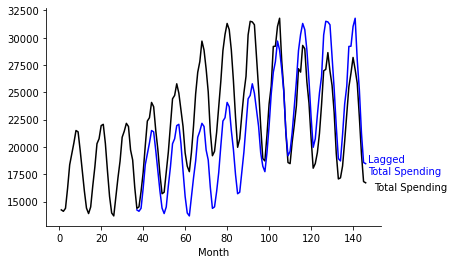

```python
lag = 36
df['lag36'] = np.NaN
for i in range(len(df['lag36']))[lag:]:
    df['lag36'].iloc[i] = df['Public Construction'].iloc[i-36]
print(df.head)

for i in range(int(len(df.index)/2)):
    print('autocorrelation, lag =',i,':',df.R1.autocorr(lag = i))

fig,ax = plt.subplots()
ax.plot(df.Month,x2,c='k')
ax.plot(df.Month,df.lag36,c='b')
ax.text(150,16000,'Total Spending',color='k')
ax.text(147,17500,'Lagged\nTotal Spending',color='b')
ax.spines['right'].set_visible(False)
ax.spines['top'].set_visible(False)

ax.set_xlabel('Month')
```

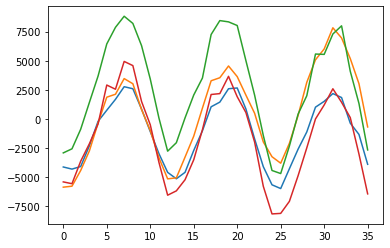

```python
dfm = pd.DataFrame()
cycleLen = 36
for i in range(int(len(df.index)/cycleLen)):
    newData = pd.DataFrame({i:df['R1'].iloc[i*cycleLen:(i+1)*cycleLen]})
    newData.index = range(0,len(newData))
    dfm = pd.concat([dfm,newData],axis=1)

fig,ax = plt.subplots()
ax.plot(dfm)
```

[output not shown]

[output cut: 22 more lines]

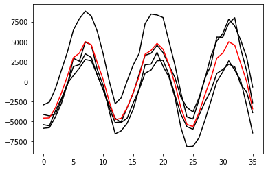

```python
avg = []
for i in range(len(dfm.index)):
    avg.append(dfm.iloc[i].mean())

dfm = pd.concat([dfm,pd.DataFrame({'avg':avg})], axis=1)
print(dfm)

fig,ax = plt.subplots()
c = 180
for col in dfm.columns.values:
    if col == 'avg':
        ax.plot(dfm[col], c = 'r')
    else:
        ax.plot(dfm[col], c = 'k')
```

- We are going to find out the Remainder, R2, using R1 and subtracting the avarage seasonality:

```python
df['S'] = np.NaN
df['R2'] = np.NaN
df['Composite'] = np.NaN
df['errorPerc'] = np.NaN
S = dfm['avg'].tolist()
for i in df.index:
    df.loc[i,'S'] = S[i%cycleLen]
    df.loc[i,'R2'] = df.loc[i,'R1'] - df.loc[i,'S']
    df.loc[i,'Composite'] = df.loc[i,'regress'] + df.loc[i,'S']
    df.loc[i,'errorPerc'] = 100*df.loc[i,'R2'] / df.loc[i,'Public Construction']
df.style.format({
    'Public Construction': '{:,.0f}'.format,
    'regress': '{:,.0f}'.format,
    'R1': '{:,.0f}'.format,
    'S': '{:,.0f}'.format,
    'R2': '{:,.0f}'.format,
    'Composite':'{:,.0f}'.format,
    'errorPerc': '{:.2f}%'.format
})
```

|  | Month | Month-Year | Total Construction | Private Construction | Public Construction | regress | R1 | S | R2 | Composite | errorPerc |
| --- | --- | --- | --- | --- | --- | --- | --- | --- | --- | --- | --- |
| 0 | 1 | Jan-02 | 59516 | 45273 | 14,243 | 18,380 | -4,137 | -4,588 | 451 | 13,792 | 3.17% |
| 1 | 2 | Feb-02 | 58588 | 44475 | 14,113 | 18,432 | -4,319 | -4,564 | 245 | 13,868 | 1.73% |
| 2 | 3 | Mar-02 | 63782 | 49396 | 14,386 | 18,484 | -4,098 | -3,267 | -831 | 15,217 | -5.78% |
| 3 | 4 | Apr-02 | 69504 | 53283 | 16,221 | 18,536 | -2,315 | -1,449 | -866 | 17,087 | -5.34% |
| 4 | 5 | May-02 | 73384 | 55009 | 18,375 | 18,588 | -213 | 669 | -882 | 19,257 | -4.80% |
| 5 | 6 | Jun-02 | 77182 | 57801 | 19,381 | 18,640 | 741 | 2,987 | -2,246 | 21,627 | -11.59% |
| 6 | 7 | Jul-02 | 78863 | 58494 | 20,369 | 18,692 | 1,677 | 3,551 | -1,874 | 22,243 | -9.20% |
| 7 | 8 | Aug-02 | 79460 | 57953 | 21,507 | 18,744 | 2,763 | 4,995 | -2,232 | 23,739 | -10.38% |
| 8 | 9 | Sep-02 | 76542 | 55157 | 21,385 | 18,796 | 2,589 | 4,596 | -2,007 | 23,392 | -9.39% |
| 9 | 10 | Oct-02 | 75710 | 56023 | 19,687 | 18,848 | 839 | 2,355 | -1,516 | 21,203 | -7.70% |
| 10 | 11 | Nov-02 | 71362 | 53552 | 17,810 | 18,900 | -1,090 | 210 | -1,300 | 19,110 | -7.30% |
| 11 | 12 | Dec-02 | 63984 | 48023 | 15,961 | 18,952 | -2,991 | -2,503 | -488 | 16,449 | -3.06% |
| 12 | 13 | Jan-03 | 59877 | 45473 | 14,404 | 19,004 | -4,600 | -4,774 | 174 | 14,230 | 1.21% |
| 13 | 14 | Feb-03 | 58526 | 44620 | 13,906 | 19,056 | -5,150 | -4,616 | -534 | 14,440 | -3.84% |
| 14 | 15 | Mar-03 | 64506 | 49996 | 14,510 | 19,108 | -4,598 | -3,259 | -1,339 | 15,849 | -9.23% |
| 15 | 16 | Apr-03 | 69638 | 53195 | 16,444 | 19,160 | -2,716 | -1,419 | -1,298 | 17,742 | -7.89% |
| 16 | 17 | May-03 | 74473 | 56286 | 18,187 | 19,212 | -1,025 | 619 | -1,644 | 19,831 | -9.04% |
| 17 | 18 | Jun-03 | 80377 | 60076 | 20,301 | 19,264 | 1,037 | 3,414 | -2,377 | 22,678 | -11.71% |
| 18 | 19 | Jul-03 | 82971 | 62216 | 20,755 | 19,316 | 1,439 | 3,898 | -2,459 | 23,214 | -11.85% |
| 19 | 20 | Aug-03 | 85191 | 63234 | 21,957 | 19,368 | 2,589 | 4,781 | -2,193 | 24,150 | -9.99% |
| 20 | 21 | Sep-03 | 83841 | 61767 | 22,075 | 19,420 | 2,655 | 4,052 | -1,398 | 23,473 | -6.33% |
| 21 | 22 | Oct-03 | 83133 | 62813 | 20,321 | 19,472 | 849 | 2,109 | -1,260 | 21,581 | -6.20% |
| 22 | 23 | Nov-03 | 77915 | 60115 | 17,801 | 19,524 | -1,723 | -299 | -1,424 | 19,225 | -8.00% |
| 23 | 24 | Dec-03 | 71050 | 55584 | 15,466 | 19,576 | -4,110 | -3,331 | -779 | 16,245 | -5.04% |
| 24 | 25 | Jan-04 | 64934 | 50975 | 13,959 | 19,628 | -5,669 | -5,383 | -286 | 14,245 | -2.05% |
| 25 | 26 | Feb-04 | 64138 | 50449 | 13,689 | 19,680 | -5,991 | -5,658 | -334 | 14,023 | -2.44% |
| 26 | 27 | Mar-04 | 73238 | 57796 | 15,443 | 19,732 | -4,289 | -3,955 | -334 | 15,777 | -2.16% |
| 27 | 28 | Apr-04 | 78354 | 61177 | 17,177 | 19,784 | -2,607 | -1,701 | -907 | 18,084 | -5.28% |
| 28 | 29 | May-04 | 83736 | 65027 | 18,709 | 19,836 | -1,127 | 376 | -1,504 | 20,213 | -8.04% |
| 29 | 30 | Jun-04 | 89932 | 69039 | 20,893 | 19,888 | 1,005 | 2,911 | -1,906 | 22,799 | -9.12% |

[output cut: 116 more lines]

Next step, let's see how the model fits to actual spending:

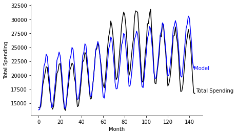

```python
fig, ax = plt.subplots()
ax.plot(df['Public Construction'],c='k')
ax.plot(df['Composite'],c='b')
ax.text(146,17000,'Total Spending', color='k')
ax.text(144,21000,'Model', color='b')
ax.spines['top'].set_visible(False)
ax.spines['right'].set_visible(False)
ax.set_xlabel('Month')
ax.set_ylabel('Total Spending')
```

- Let's check the Remainder, which is the error of the model:

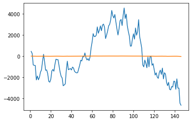

```python
plt.plot(df.Month,df.R2)
plt.plot(df.Month,df.errorPerc)
```